# Lab6: ANOVA and Chi-square Tests

**Xiaofan Liang** **July 30th, 2025**

**and Zhixuan Qi** **Updated on Oct 8th, 2026**

## Learning Objectives

By the end of this practical lab you will be able to:

- Run ANOVA tests with `aov()`
- Conduct ANOVA posthoc tests (TukeyHSD) with `TukeyHSD()`
- Create contingency table with `table()`
- Run Chi-square tests with `chisq.test()`
- Conduct Chi-square posthoc tests with `chisq.posthoc.test()`

**CHEATSHEETS!** You are encouraged to download RStudio Cheatsheets. You can find them on RStudio website [here](https://posit.co/resources/cheatsheets/?type=posit-cheatsheets/), or a comprehensive list (more than what has been listed) [here](https://github.com/rstudio/cheatsheets/). For example, here you can find [base R syntax](https://rstudio.github.io/cheatsheets/base-r.pdf), [dplyr](https://rstudio.github.io/cheatsheets/data-transformation.pdf) (which contains most of the functions for data wrangling in tidyverse), and [ggplot2](https://rstudio.github.io/cheatsheets/data-visualization.pdf).

New functions are summarized below:

| Functions | [Package If Any] Tasks |
| --- | --- |
| `cut()` | Divides a numeric vector into intervals, or labeled “bins” |
| `aov()` | Performs one and two sample t-tests on vectors of data |
| `TukeyHSD()` | Computes Tukey Honest Significant Differences, a posthoc analysis of the ANOVA model |
| `table()` | Builds a contingency table of the counts at each combination of factor levels. |
| `chisq.test()` | Performs Pearson’s Chi-squared test for count data |
| `chisq.posthoc.test()` | [chisq.posthoc.test] Performs post hoc analysis based on residuals of Pearson’s Chi-squared test for count data. |

[zhixuan’s comment]: the `aov()` row above was copied from `t.test()` in Lab 5. `aov()` doesn’t run t-tests. It fits an analysis of variance (ANOVA) model, which compares the means of three or more groups. Also, `quantile()` is used with `cut()` below but isn’t in this table. It returns the values at given percentiles (here the 33rd and 66th), and `cut()` uses those values as the bin edges.

## ANOVA: Comparing Mean Difference between Three Groups or Above

In Lab 5, we learned to apply t-tests to see the statistical significance of mean difference between two groups. ANOVA is also used to compare mean difference but for more than two categorical groups. Let’s pick a different variable, `walkscore`, and explores its relationship with chain restaurants.

**The goal of the following ANOVA analysis is to determine if there are statistically significant differences in the mean `chain_pct` between low-walkability, middle-walkability, and high-walkability MSAs**.

### Set Environment and Import Data

```r
# set environment
#setwd("/Users/xfliang/University of Michigan Dropbox/Xiaofan Liang/UM_Teaching/URP506_F25/Lab/Lab6/")
# load tidyverse libraries
library(tidyverse)
# import data
chainness_joined <- read.csv('chainness_by_MSA_joined.csv')
head(chainness_joined)
```

```
##   MSA_GEOID                    MSA_NAME avg_frequency chain_pct trump_pct
## 1     10180                 Abilene, TX      1891.306 0.5220418 0.7430254
## 2     10420                   Akron, OH      1520.445 0.4189992 0.4614866
## 3     10500                  Albany, GA      2335.204 0.5308311 0.3954108
## 4     10540          Albany-Lebanon, OR      1292.266 0.2824859 0.5703094
## 5     10580 Albany-Schenectady-Troy, NY      1184.278 0.2931091 0.4224509
## 6     10740             Albuquerque, NM      1479.655 0.4356347 0.3630682
##   majority_vote median_income pop_density walkscore
## 1         Trump      45866.06    1915.434  32.93527
## 2       Clinton      61193.06    1877.223  25.85064
## 3       Clinton      40240.01    1272.335  25.53003
## 4         Trump      44985.53    1662.182  36.60056
## 5       Clinton      62549.83    3797.303  40.97887
## 6       Clinton      46889.95    3448.244  44.57452
```

### Create a `walkability_level` column

Our dataset does not have a column that contains more than two unique categorical values. For demonstration purposes, we will create a new column called `walkability_level` with values `low-walkability`, `middle-walkability`, and `high-walkability`. All MSAs are divided into three walkability groups using the `quantile()` and `cut()` function (run `?cut` to learn more). If a MSA’s walk score is between 0% and 33% percentiles, then it is considered as “low-walkability”; if between 33% to 66%, then “middle-walkability”; if between 66% to 100%, then “high-walkability”.

```r
# create a new walkability_level column in base R
chainness_joined$walkability_level <- cut(
  chainness_joined$walkscore,
  breaks = quantile(chainness_joined$walkscore, probs = c(0, 0.33, 0.66, 1), na.rm = TRUE),
  labels = c("low-walkability", "middle-walkability", "high-walkability"),
  include.lowest = TRUE
)

# check if walkability_level column is created
head(chainness_joined)
```

```
##   MSA_GEOID                    MSA_NAME avg_frequency chain_pct trump_pct
## 1     10180                 Abilene, TX      1891.306 0.5220418 0.7430254
## 2     10420                   Akron, OH      1520.445 0.4189992 0.4614866
## 3     10500                  Albany, GA      2335.204 0.5308311 0.3954108
## 4     10540          Albany-Lebanon, OR      1292.266 0.2824859 0.5703094
## 5     10580 Albany-Schenectady-Troy, NY      1184.278 0.2931091 0.4224509
## 6     10740             Albuquerque, NM      1479.655 0.4356347 0.3630682
##   majority_vote median_income pop_density walkscore  walkability_level
## 1         Trump      45866.06    1915.434  32.93527 middle-walkability
## 2       Clinton      61193.06    1877.223  25.85064    low-walkability
## 3       Clinton      40240.01    1272.335  25.53003    low-walkability
## 4         Trump      44985.53    1662.182  36.60056 middle-walkability
## 5       Clinton      62549.83    3797.303  40.97887   high-walkability
## 6       Clinton      46889.95    3448.244  44.57452   high-walkability
```

Optionally, this is the syntax in `tidyverse`. `cut()` is a base R function. The difference lies in how you create a column (e.g., `mutate()` is a tidyverse function) and whether you call the dataset `chainness_joined` to retrieve columns.

```r
# create a new walkability_level column
chainness_joined <- chainness_joined %>%
  mutate(walkability_level = cut(
    walkscore,
    breaks = quantile(walkscore, probs = c(0, 0.33, 0.66, 1), na.rm=T),
    labels = c("low-walkability", "middle-walkability", "high-walkability"),
    include.lowest = TRUE
  ))
```

### ANOVA tests

The `aov()` function in R is used to perform analysis of variance (ANOVA). The `aov()` function fits an ANOVA model to the data, examining how the mean percentage of chain restaurants (`chain_pct`) varies across different levels of walkability (`walkability_level`). The variable to the left of `~` symbol is the dependent variable.

```r
# Perform ANOVA
anova_result <- aov(chain_pct ~ walkability_level, data = chainness_joined)

# Display the summary of the ANOVA test
summary(anova_result)
```

```
##                    Df Sum Sq Mean Sq F value   Pr(>F)
## walkability_level   2 0.4647 0.23235   34.79 1.36e-14 ***
## Residuals         377 2.5177 0.00668
## ---
## Signif. codes:  0 '***' 0.001 '**' 0.01 '*' 0.05 '.' 0.1 ' ' 1
```

### Interpret ANOVA test results

The ANOVA results table provides the following key statistics. **Among all the statistics, P-value (Pr(>F)) is the one used to most to determine the statistical significance of the test**. * **Df**: The degrees of freedom for walkability_level is 2, indicating there are three levels of walkability (low, middle, and high). The degrees of freedom for Residuals is 377, representing the number of observations minus the number of groups.

- **Sum Sq (Sum of Squares)**: walkability_level: 0.4647 is the variability in the percentage of chain restaurants that can be explained by the walkability levels. Residuals: 2.5177 is the variability that cannot be explained by the walkability levels (i.e., the within-group variability).
- **Mean Sq (Mean Squares)**: walkability_level: 0.23235 is the average variability explained by the walkability levels. Residuals: 0.00668 is the average within-group variability.
- **F value**: The F value of 34.79 indicates the ratio of the mean square of the walkability levels to the mean square of the residuals. A higher F value indicates that the variability between groups (walkability levels) is much larger than the variability within groups.
- **p-value**: The p-value of 1.36e-14 is extremely small, far below the common significance level thresholds (e.g., 0.05, 0.01, 0.001). This indicates a very strong evidence against the null hypothesis.

Again, you don’t need to interpret every variable above in a statistical interpretation. The key one is **p-value** and it is often interpreted with original hypothesis in context.

For example, the ANOVA results show that there is a statistically significant difference in the percentage of chain restaurants among the different walkability levels. The extremely low p-value (1.36e-14) indicates that the differences observed are not due to random chance. Therefore, we reject the null hypothesis that the means of the percentage of chain restaurants are equal across the different levels of walkability.

[zhixuan’s comment]: careful with “the differences observed are not due to random chance” above. A p-value can’t prove that. It tells us that if the three group means were really equal, differences this large would almost never show up (p = 1.36e-14). So the safer wording is that the differences are very unlikely to be due to random chance alone.

### ANOVA posthoc test: Tukey’s HSD test

While ANOVA determines whether the mean difference is statistically significant, further post-hoc analysis (such as Tukey’s HSD test) would be needed to determine which specific groups differ from each other. It is called a post-hoc analysis because you need to run the ANOVA model first.

```r
# Perform Tukey's HSD test
tukey_result <- TukeyHSD(anova_result)

# Print the result
print(tukey_result)
```

```
##   Tukey multiple comparisons of means
##     95% family-wise confidence level
##
## Fit: aov(formula = chain_pct ~ walkability_level, data = chainness_joined)
##
## $walkability_level
##                                            diff         lwr         upr
## middle-walkability-low-walkability  -0.04725876 -0.07153316 -0.02298436
## high-walkability-low-walkability    -0.08525157 -0.10933631 -0.06116684
## high-walkability-middle-walkability -0.03799281 -0.06212623 -0.01385939
##                                         p adj
## middle-walkability-low-walkability  0.0000188
## high-walkability-low-walkability    0.0000000
## high-walkability-middle-walkability 0.0007115
```

The Tukey HSD test results are shown for pairwise comparisons between the levels of walkability_level. Here’s a breakdown of the first comparison (middle-walkability vs. low-walkability)

- **Difference (diff)**: -0.04725876. This indicates that the mean percentage of chain restaurants in middle-walkability areas is approximately 4.73 percentage points lower than in low-walkability areas.
- **Lower Bound (lwr)**: -0.07153316. The lower bound of the 95% confidence interval for the difference in means is approximately -7.15 percentage points.
- **Upper Bound (upr)**: -0.02298436. The upper bound of the 95% confidence interval for the difference in means is approximately -2.30 percentage points.
- **Adjusted p-value (p adj)**: 0.0000188. The p-value is very small, indicating that the difference in means is statistically significant at the 95% confidence level. The small p-value suggests that the observed difference is unlikely to be due to random chance.

In summary:

The mean percentage of chain restaurants decreases significantly as walkability increases, with middle-walkability areas averaging about 4.73 percentage points lower than low-walkability areas, high-walkability areas about 8.53 points lower than low-walkability areas, and high-walkability areas about 3.80 points lower than middle-walkability areas.

### Tukey’s HSD test visualization (Optional)

You can also visualize the results like below:

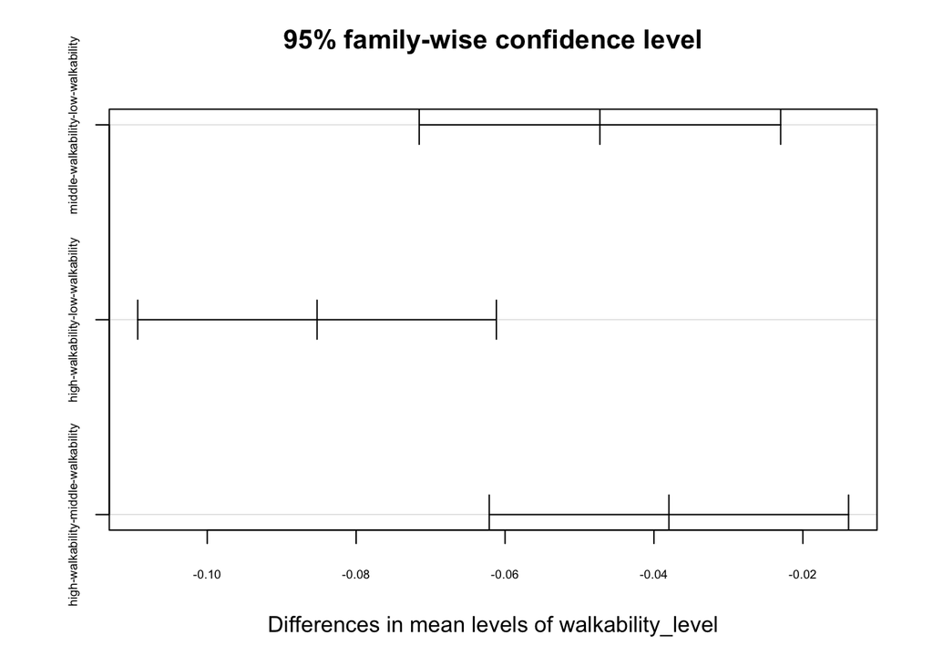

```r
# Optionally, you can visualize the results
plot(tukey_result, cex.axis=0.55)
```

The easy base R `plot()` function can give you a quick visualization for TukeyHSD results, but you cannot edit the plot elements easily (e.g., change x-axis and y-axis labels) (see [this Stack Overflow post](https://stackoverflow.com/questions/60794019/how-to-edit-a-tukey-test-plot-in-r) for this annoying nuance).

The y-axis represents the pairs of groups being compared. Each label on the y-axis corresponds to a specific pairwise comparison between the levels of the independent variable (e.g., “high-walkability - middle-walkability”).

The x-axis represents the difference in means between the pairs of groups being compared. Each point on the x-axis shows the estimated difference in means between two levels of the independent variable (in this case, walkability_level).

This plot, while easy to produce, is less intuitive to interpret. The optional section shows an advanced version.

```r
tukey_df <- as.data.frame(tukey_result$walkability_level)
tukey_df
```

```
##                                            diff         lwr         upr
## middle-walkability-low-walkability  -0.04725876 -0.07153316 -0.02298436
## high-walkability-low-walkability    -0.08525157 -0.10933631 -0.06116684
## high-walkability-middle-walkability -0.03799281 -0.06212623 -0.01385939
##                                            p adj
## middle-walkability-low-walkability  0.0000187511
## high-walkability-low-walkability    0.0000000000
## high-walkability-middle-walkability 0.0007114593
```

```r
tukey_df$Comparison <- rownames(tukey_df)
rownames(tukey_df) <- NULL

tukey_df
```

```
##          diff         lwr         upr        p adj
## 1 -0.04725876 -0.07153316 -0.02298436 0.0000187511
## 2 -0.08525157 -0.10933631 -0.06116684 0.0000000000
## 3 -0.03799281 -0.06212623 -0.01385939 0.0007114593
##                            Comparison
## 1  middle-walkability-low-walkability
## 2    high-walkability-low-walkability
## 3 high-walkability-middle-walkability
```

We will use points to represent the mean difference and error bars to represent the range of 95% confidence interval.

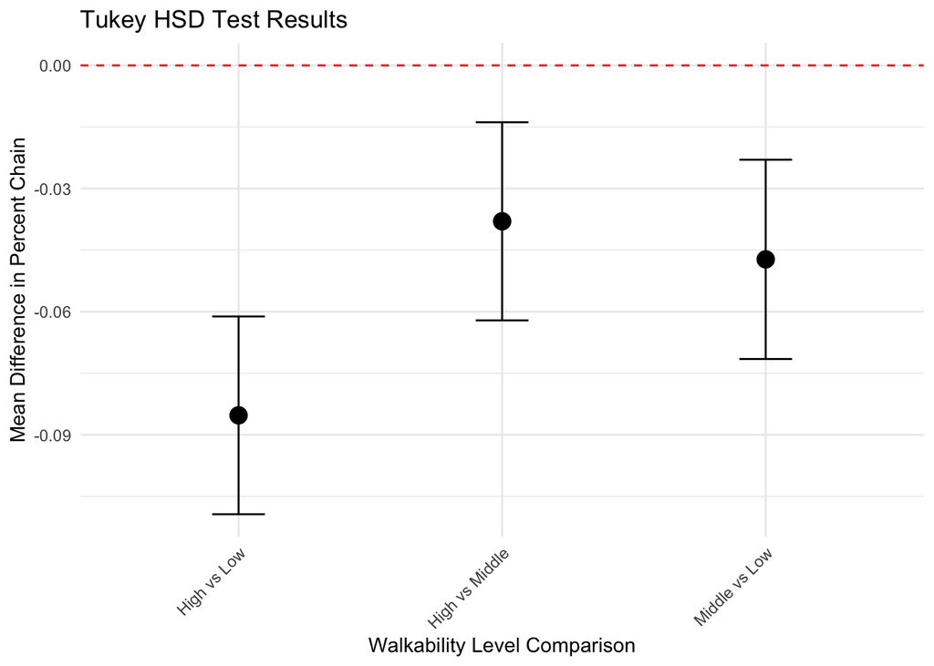

```r
# Create a ggplot visualization with a box plot
ggplot(tukey_df, aes(x = Comparison, y = diff)) +
  geom_point(size = 4) +
  geom_errorbar(aes(ymin = lwr, ymax = upr), width = 0.2) +
  geom_hline(yintercept = 0, linetype = "dashed", color = "red") +
  labs(title = "Tukey HSD Test Results",
       x = "Walkability Level Comparison",
       y = "Mean Difference in Percent Chain") +
  scale_x_discrete(labels = c("High vs Low", "High vs Middle", "Middle vs Low")) +
  theme_minimal() +
  theme(axis.text.x = element_text(angle = 45, hjust = 1))
```

[zhixuan’s comment]: the comment in the chunk above says “box plot”, but this isn’t a box plot. Each point is the mean difference for one pair, and each error bar is that pair’s 95% confidence interval.

## Contingency Table

A contingency table, also known as a cross-tabulation or crosstab, is a type of table that displays the frequency distribution of variables. It helps in examining the relationship between two or more categorical variables by showing how the categories of one variable are distributed across the categories of another variable. It can also be used directly as an input for the Chi-square tests below. Each cell in the table represents the count or frequency of observations that fall into the corresponding categories.

Our dependent variable, `chain_pct` is a continuous variable. To examine its relationship with other variables through contingency table and chi-square test, we will have to convert it into a categorical variable like `walkability_level`. Again, this is not the most effective technique for this dataset because our variables are mostly represented as continuous variables, but we will keep it simple for code demonstration. Chi-square tests are typically used for survey analysis because many survey questions are framed as categories.

```r
# create a chain_level
chainness_joined$chain_level <- cut(
    chainness_joined$chain_pct,
    breaks = quantile(chainness_joined$chain_pct, probs = c(0, 0.33, 0.66, 1), na.rm=T),
    labels = c("low-chain", "middle-chain", "high-chain"),
    include.lowest = TRUE
  )
head(chainness_joined)
```

```
##   MSA_GEOID                    MSA_NAME avg_frequency chain_pct trump_pct
## 1     10180                 Abilene, TX      1891.306 0.5220418 0.7430254
## 2     10420                   Akron, OH      1520.445 0.4189992 0.4614866
## 3     10500                  Albany, GA      2335.204 0.5308311 0.3954108
## 4     10540          Albany-Lebanon, OR      1292.266 0.2824859 0.5703094
## 5     10580 Albany-Schenectady-Troy, NY      1184.278 0.2931091 0.4224509
## 6     10740             Albuquerque, NM      1479.655 0.4356347 0.3630682
##   majority_vote median_income pop_density walkscore  walkability_level
## 1         Trump      45866.06    1915.434  32.93527 middle-walkability
## 2       Clinton      61193.06    1877.223  25.85064    low-walkability
## 3       Clinton      40240.01    1272.335  25.53003    low-walkability
## 4         Trump      44985.53    1662.182  36.60056 middle-walkability
## 5       Clinton      62549.83    3797.303  40.97887   high-walkability
## 6       Clinton      46889.95    3448.244  44.57452   high-walkability
##    chain_level
## 1   high-chain
## 2 middle-chain
## 3   high-chain
## 4    low-chain
## 5    low-chain
## 6 middle-chain
```

```r
# ---- tidyverse equivalent ----- #
# chainness_joined <- chainness_joined %>% mutate(
#   chain_level = cut(
#     chain_pct,
#     breaks = quantile(chain_pct, probs = c(0, 0.33, 0.66, 1), na.rm=T),
#     labels = c("low-chain", "middle-chain", "high-chain"),
#     include.lowest = TRUE
#   ))
```

You can use `table()` function (base R) to create a contingency table for two categorical variables (i.e., `walkability_level` and `chain_level`). Type `?table()` in console and a help page will pop up under the Help tab on bottom right of the R Studio interface. Click on Cross Tabulation and Table Creation to see the details of the function.

```r
contingency_table <- table(chainness_joined$chain_level, chainness_joined$walkability_level)
contingency_table
```

```
##
##                low-walkability middle-walkability high-walkability
##   low-chain                 21                 43               62
##   middle-chain              35                 43               47
##   high-chain                70                 39               20
```

You can also achieve the same data with a long table (rather than a wide table like above) using the `group_by()` and `summarise()` functions.

```r
chainness_joined %>% group_by(chain_level, walkability_level) %>% summarise(n=n())
```

```
## `summarise()` has regrouped the output.
## ℹ Summaries were computed grouped by chain_level and walkability_level.
## ℹ Output is grouped by chain_level.
## ℹ Use `summarise(.groups = "drop_last")` to silence this message.
## ℹ Use `summarise(.by = c(chain_level, walkability_level))` for per-operation
##   grouping (`?dplyr::dplyr_by`) instead.
```

```
## # A tibble: 9 × 3
## # Groups:   chain_level [3]
##   chain_level  walkability_level      n
##   <fct>        <fct>              <int>
## 1 low-chain    low-walkability       21
## 2 low-chain    middle-walkability    43
## 3 low-chain    high-walkability      62
## 4 middle-chain low-walkability       35
## 5 middle-chain middle-walkability    43
## 6 middle-chain high-walkability      47
## 7 high-chain   low-walkability       70
## 8 high-chain   middle-walkability    39
## 9 high-chain   high-walkability      20
```

## Chi-square test

The **Chi-square test** is a statistical test used to determine if there is a significant association between two categorical variables. It is often used in conjunction with a contingency table to test the null hypothesis that the variables are independent, meaning there is no relationship between them.

- **Test Statistic:** The Chi-square test statistic is calculated based on the difference between observed and expected frequencies in the contingency table. The formula is:

  $$\chi^2 = \sum \frac{(O_i - E_i)^2}{E_i}$$

  where $O_i$ is the observed frequency, and $E_i$ is the expected frequency for each cell in the table.

When applied to the contingency table above, Chi-square tests can answer whether there is an association between MSAs’ level of percent chain and level of walkability.

```r
# Perform Chi-square test on the contingency table; this table corresponds to `income_group`
chi_square_result <- chisq.test(contingency_table)

# Display the results of the Chi-square test
chi_square_result
```

```
##
##  Pearson's Chi-squared test
##
## data:  contingency_table
## X-squared = 51.149, df = 4, p-value = 2.078e-10
```

[zhixuan’s comment]: the comment in the chunk above says the table “corresponds to `income_group`”. That’s left over from an older version of this lab. `contingency_table` is `chain_level` by `walkability_level`.

### Interpret Chi-square test results

Interpretations:

- **The X-squared statistic** measures the difference between the observed frequencies in the contingency table and the frequencies expected if `chain_level` and `walkability_level` were independent.
- **The degrees of freedom** for a chi-square test in a contingency table are calculated as (number of rows−1)×(number of columns−1). In this case, the degrees of freedom are 4, indicating the table likely has 3 rows and 3 columns
- **The p-value** indicates the probability of observing a chi-squared statistic as extreme as 51.149, or more so, under the null hypothesis that `chain_level` and `walkability_level` are independent. This strongly suggests that the observed association is highly unlikely to be due to chance.

The chi-square test results indicate a highly significant association between `chain_level` and `walkability_level`. The extremely small p-value (2.078e-10) provides strong evidence against the null hypothesis of independence. This implies that the prevalence of chain restaurants is likely influenced by the walkability level of the area, or vice versa.

[zhixuan’s comment]: careful with “influenced by” above. A chi-square test only shows that the two variables are associated. It can’t tell us that walkability changes the chain level (or the other way around), since another factor, like population density, could drive both. “Associated with” is the safer wording.

### Chi-square posthoc test

There is a post-hoc test for chi-square tests to determine which specific pairs of categories are significantly different. One common approach is to use pairwise comparisons with adjusted p-values to control for multiple comparisons, similar to what is done in ANOVA post-hoc tests. The R package `chisq.posthoc.test` provides a function `chisq.posthoc.test()` that perform posthoc analysis based on residuals of the chi-square test.

[zhixuan’s comment]: the text above says the posthoc test finds which “pairs of categories” differ, but `chisq.posthoc.test()` works cell by cell. For each cell in the contingency table, it checks whether the observed count is much higher or lower than expected (the residual), and adjusts the p-values for the 9 cells tested. That’s why the output below has a residual and a p-value for each chain level and walkability level combination, not one per pair.

```r
# install.packages('chisq.posthoc.test')
library(chisq.posthoc.test)
# Perform pairwise comparisons with adjusted p-values through bonferroni method
posthoc_result <- chisq.posthoc.test(contingency_table, method = 'bonferroni')
posthoc_result
```

```
##      Dimension     Value low-walkability middle-walkability high-walkability
## 1    low-chain Residuals       -4.809442          0.3600946         4.424229
## 2    low-chain  p values        0.000014          1.0000000         0.000087
## 3 middle-chain Residuals       -1.495308          0.4372680         1.052772
## 4 middle-chain  p values        1.000000          1.0000000         1.000000
## 5   high-chain Residuals        6.265135         -0.7918547        -5.443081
## 6   high-chain  p values        0.000000          1.0000000         0.000000
```

Let’s take the first row as an example for interpretation. The low-chain category is significantly underrepresented in low-walkability areas (negative residual -4.8 and very low p-value). It is significantly overrepresented in high-walkability areas (positive residual +4.4 and very low p-value). There is no significant difference for middle-walkability areas.

In summary, low-chain restaurants (i.e., independent restaurant) are less common in low-walkability areas and more common in high-walkability areas. Middle-chain restaurants are evenly distributed across all walkability levels. High-chain restaurants are more common in low-walkability areas and less common in high-walkability areas.

### (Optional) Visualize Chi-square Posthoc Tests

To visualize the outcome of the chi-square posthoc test, we can create a heatmap to display the standardized residuals. This will help in understanding which cells contribute most to the significant chi-square test result.

```r
# convert the wide table to long table for ggplot2
viz_data <- posthoc_result %>% filter(Value == 'Residuals') %>% select(-c(Value)) %>%
  pivot_longer(cols = `low-walkability`:`high-walkability`,
               names_to = "Walkability_Level",
               values_to = "Residuals") %>%
  rename(Chain_Level = Dimension)

head(viz_data)
```

```
## # A tibble: 6 × 3
##   Chain_Level  Walkability_Level  Residuals
##   <chr>        <chr>                  <dbl>
## 1 low-chain    low-walkability       -4.81
## 2 low-chain    middle-walkability     0.360
## 3 low-chain    high-walkability       4.42
## 4 middle-chain low-walkability       -1.50
## 5 middle-chain middle-walkability     0.437
## 6 middle-chain high-walkability       1.05
```

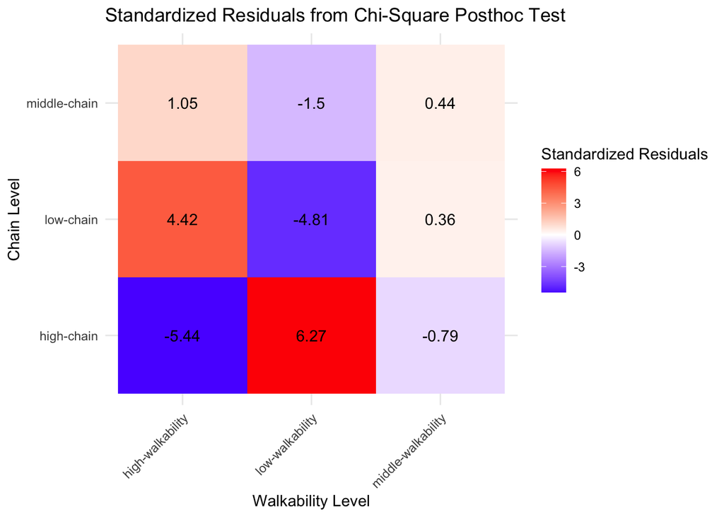

```r
# Create heatmap for residuals with significance highlight
ggplot(viz_data, aes(x = Walkability_Level, y = Chain_Level, fill = Residuals)) +
  geom_tile() +
  scale_fill_gradient2(low = "blue", mid = "white", high = "red", midpoint = 0,
                       name = "Standardized Residuals") +
  geom_text(aes(label = round(Residuals, 2)), color = "black") +
  labs(title = "Standardized Residuals from Chi-Square Posthoc Test",
       x = "Walkability Level",
       y = "Chain Level") +
  theme_minimal() +
  theme(axis.text.x = element_text(angle = 45, hjust = 1))
```

## Practice Questions

We will reproduce the analysis above but with the `pop_density` variable. Please create a new column called `pop_density_level` in `chainness_joined` table. If a MSA’s population density is between 0% and 33% percentiles, then it is considered as “low-density”; if between 33% to 66%, then “middle-density”; if between 66% to 100%, then “high-density”.

### Q1

Aim: to practice setting up hypotheses tests with ANOVA and interpreting their results.

Conduct an ANOVA and posthoc test to examine the relationship between chain restaurant and population density, using the `chainness_joined` table. What is the null and alternative hypothesis? Which variables should you use? Which pair has the greatest mean difference and is it statistically significant?

### Q2

Aim: to practice creating contingency tables to summarize categorical data.

Compute a contingency table to show relationship between chain restaurant and population density. What variables should you use? How many low-density MSAs are also high in percent chain? [Hint: 67]

### Q3

Aim: to practice using chi-squared to test for associations between categorical variables.

Conduct a chi-square and posthoc test to examine the relationship between chain restaurant and population density. What can you conclude from the results?